# Portfoliomanagement and Financial Analysis - Assignment 2

## Exercise 2: The mu/sigma diagram

For the 10 stocks in your sample, calculate mu and sigma for the entire and 3 subperiods. Plot all four combinations in a mu-sigma diagram.

Next, use the power of `tsibble` to calculate rolling/growing versions of mu and sigma (e.g. start with 6 months of data). Try to plot the changing mu and sigma via an animation using `gganimate` (see [here](https://www.datanovia.com/en/blog/gganimate-how-to-create-plots-with-beautiful-animation-in-r/)).

[output not shown]

[output cut: 46 more lines]

[output not shown]

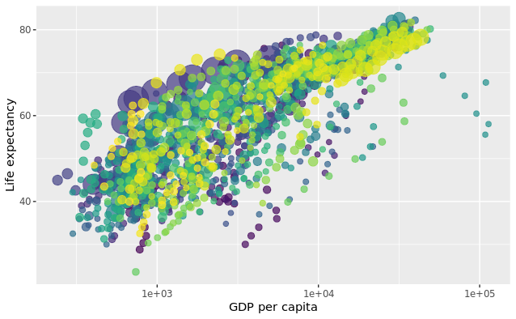

```r
pacman::p_load(gganimate,gifski,png,gapminder)
p <- ggplot(
gapminder,
aes(x = gdpPercap, y=lifeExp, size = pop, colour = country)
) +
geom_point(show.legend = FALSE, alpha = 0.7) +
scale_color_viridis_d() +
scale_size(range = c(2, 12)) +
scale_x_log10() +
labs(x = "GDP per capita", y = "Life expectancy")
p
p + transition_time(year) +
labs(title = "Year: {frame_time}")
```

stock selection

```r
stockselection <- c( "AAPL","MSFT", "JPM", "AMZN", "NOV", "T", "BAC", "INTC", "CVX", "CSCO")

stocks.prices <- stockselection %>%
  tq_get(get  = "stock.prices", from = "2000-01-01",to = "2019-12-31") %>%
  group_by(symbol) #get all stock prices and sort them by symbol

stocks.returns.monthly <- stocks.prices %>%
  tq_transmute(select = adjusted,
               mutate_fun = periodReturn,
               period="monthly",
               type="arithmetic",
               col_rename = "Stock.returns")

fourstockselection <- c("AAPL", "MSFT", "BAC", "JPM")
```

stock prices from 2000-2019

```r
stocks.prices.20002019 <- stockselection %>%
  tq_get(get  = "stock.prices", from = "2000-01-01",to = "2019-12-31") %>%
  group_by(symbol) #get all stock prices and sort them by symbol
```

create monthly returns

```r
stocks.returns.monthly.20002019 <- stocks.prices.20002019 %>%
  tq_transmute(select = adjusted,
               mutate_fun = periodReturn,
               period="monthly",
               type="arithmetic",
               col_rename = "Stock.returns")

meanstocks20002019 <- stocks.returns.monthly %>%
    group_by(symbol) %>%
    summarize(mu = mean(Stock.returns, na.rm=TRUE))

sdstocks20002019 <- stocks.returns.monthly %>%
    group_by(symbol) %>%
      summarize(sigma = sd(Stock.returns, na.rm=TRUE))
```

Create 3 Subperiods 2000-2006, 2007-2013, 2014-2019. First create montly returns and then search the mean (mu) and the sandard devaiation (sigma)

```r
stocks.prices.20002006 <- stockselection %>%
  tq_get(get  = "stock.prices", from = "2000-01-01",to = "2006-12-31") %>%
  group_by(symbol) #get all stock prices and sort them by symbol
```

Subperiod 2000-2006

```r
stocks.returns.monthly.20002006 <- stocks.prices.20002006 %>%
  tq_transmute(select = adjusted,
               mutate_fun = periodReturn,
               period="monthly",
               type="arithmetic",
               col_rename = "Stock.returns")

meanstocks20002006 <- stocks.returns.monthly.20002006 %>%
    group_by(symbol) %>%
    summarize(mu = mean(Stock.returns, na.rm=TRUE))

sdstocks20002006 <- stocks.returns.monthly.20002006 %>%
    group_by(symbol) %>%
      summarize(sigma = sd(Stock.returns, na.rm=TRUE))
```

subperiod 2007-2013

```r
stocks.prices.20072013 <- stockselection %>%
  tq_get(get  = "stock.prices", from = "2007-01-01",to = "2013-12-31") %>%
  group_by(symbol) #get all stock prices and sort them by symbol

stocks.returns.monthly.20072013 <- stocks.prices.20072013 %>%
  tq_transmute(select = adjusted,
               mutate_fun = periodReturn,
               period="monthly",
               type="arithmetic",
               col_rename = "Stock.returns")

meanstocks20072013 <- stocks.returns.monthly.20072013 %>%
    group_by(symbol) %>%
    summarize(mu = mean(Stock.returns, na.rm=TRUE))

sdstocks20072013 <- stocks.returns.monthly.20072013 %>%
    group_by(symbol) %>%
      summarize(sigma = sd(Stock.returns, na.rm=TRUE))
```

subperiod 2014-2019

```r
stocks.prices.20142019 <- stockselection %>%
  tq_get(get  = "stock.prices", from = "2014-01-01",to = "2019-12-31") %>%
  group_by(symbol) #get all stock prices and sort them by symbol

stocks.returns.monthly.20142019 <- stocks.prices.20142019 %>%
  tq_transmute(select = adjusted,
               mutate_fun = periodReturn,
               period="monthly",
               type="arithmetic",
               col_rename = "Stock.returns")

meanstocks20142019 <- stocks.returns.monthly.20142019 %>%
    group_by(symbol) %>%
    summarize(mu = mean(Stock.returns, na.rm=TRUE))

sdstocks20142019 <- stocks.returns.monthly.20142019 %>%
    group_by(symbol) %>%
      summarize(sigma = sd(Stock.returns, na.rm=TRUE))
```

combine all four combination in a mu / sigma diagramm

```r
sigmamu20002019 <- merge(sdstocks20002019, meanstocks20002019,)
sigmamu20002006 <- merge(sdstocks20002006, meanstocks20002006,)
sigmamu20072013 <- merge(sdstocks20072013, meanstocks20072013,)
sigmamu20142019 <- merge(sdstocks20142019, meanstocks20142019,)
```

Combine the period and the subperiods together

```r
allsigmamu <- bind_rows(sigmamu20002006, sigmamu20072013, sigmamu20142019, sigmamu20002019); allsigmamu
```

[output not shown]

```r
NA
NA
```

Give the different periods a name to the right year

```r
allsigmamu$name<-c("Risk-Return 2000-2006","Risk-Return 2007-2013","Risk Return 2014-2019","Risk Return 2000-2019")

row.names(allsigmamu)<-c("Risk-Return 2000-2006","Risk-Return 2007-2013","Risk Return 2014-2019","Risk Return 2000-2019")

allsigmamuwithdata <- allsigmamu

allsigmamuwithdata
```

|  | sigma | mu | name |
| --- | --- | --- | --- |
| Risk-Return 2000-2006 | 0.12063508 | 0.009973717 | Risk-Return 2000-2006 |
| Risk-Return 2007-2013 | 0.10012335 | 0.012738936 | Risk-Return 2007-2013 |
| Risk Return 2014-2019 | 0.06730102 | 0.013548581 | Risk Return 2014-2019 |
| Risk Return 2000-2019 | 0.09979291 | 0.011983723 | Risk Return 2000-2019 |

```r
NA
```

install a new package to combine mü and sigma diagramm

```r
install.packages("ggrepel")
library(ggrepel)
```

going on with the names

```r
allsigmamuggplot <- ggplot(allsigmamuwithdata, aes(sigma, mu))+
  geom_point()+
  geom_label_repel(aes(label = symbol),
                  box.padding   = 0.2,
                  point.padding = 0.5,
                  label.size = 0.4,
                  segment.color = 'grey50', size = 1.5)+
  theme_classic()+
  facet_wrap(~name)

allsigmamuggplot1 <- ggplot(allsigmamuwithdata, aes(sigma, mu))+
  geom_point()+
  geom_label_repel(aes(label = symbol),
                  box.padding   = 0.4,
                  point.padding = 0.3,
                  size = 2)+
  theme_classic()+
  facet_wrap(~name, scales = "free" )#inscritption
```

Next calculate the mu and sigma daily over 6 months and then plot it to a rolling/growing animation

```r
install.packages("tidyquant")
```

```
Error in install.packages : Updating loaded packages
```

```r
require(quantmod)
require(tidyquant)
require(tidyverse)
library(quantmod)
require(ISLR)
sigmamustock_returns_daily <- fourstockselection %>%
  tq_get(get  = "stock.prices",
         from = "2019-01-01",
         to   = "2019-06-30") %>%
  group_by(symbol) %>%
  tq_transmute(select     = adjusted,
               mutate_fun = periodReturn,
               period     = "daily",
               col_rename = "Stock.returns")

Musixmonth <- sigmamustock_returns_daily %>%
  tq_transmute(select = Stock.returns,
               mutate_fun = runMean,
               n = 1, cumulative = TRUE,
               col_rename = "Mu")
Sigmasixmonth <- sigmamustock_returns_daily %>%
  tq_transmute(select = Stock.returns,
               mutate_fun = runSD,
               n = 1, cumulative = TRUE,
               col_rename = "Sigma")

nasigmamusixmonth <- left_join(Sigmasixmonth, Musixmonth)
sigmamusixmonth <- na.omit(nasigmamusixmonth)

library(ggplot2)
library(gganimate)
theme_set(theme_bw())
library(gapminder)

head(sigmamusixmonth)
```

| symbol | date | Sigma | Mu |
| --- | --- | --- | --- |
| AAPL | 2019-01-03 | 0.07043307 | -0.049803701 |
| AAPL | 2019-01-04 | 0.07302095 | -0.018972707 |
| AAPL | 2019-01-07 | 0.06020650 | -0.014785937 |
| AAPL | 2019-01-08 | 0.05429333 | -0.008016166 |
| AAPL | 2019-01-09 | 0.04962219 | -0.003849850 |
| AAPL | 2019-01-10 | 0.04537687 | -0.002843257 |

```
Removed 4 rows containing missing values (geom_point).Removed 4 rows containing missing values (geom_point).
```

[output not shown]

[output cut: 46 more lines]

[output not shown]

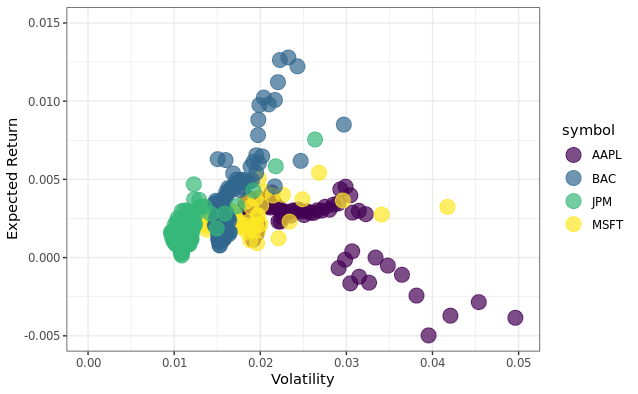

```r
p <- ggplot(sigmamusixmonth, aes(x = Sigma, y = Mu, colour = symbol)) +
  geom_point(show.legend = TRUE, alpha = 0.7, size = 5) +
  scale_color_viridis_d() +
  scale_size(range = c(2, 12)) +
  scale_x_log10() +
  labs(x = "Volatility", y = "Expected Return", colour = "symbol") +
  scale_y_continuous(breaks=seq(-0.3, 1, 0.005), limits = c(-0.005, 0.015)) +
  scale_x_continuous(breaks=seq(-0.3, 1, 0.01), limits = c(0, 0.05))
p

p + transition_time(date) +
  labs(title = "Year: {frame_time}")+
  shadow_wake(wake_length = 0.1, alpha = FALSE)
```

# we want that the points are in the left upper corner (over the indifference curve)

Example over 6 month with 7 stocks

```r
sevenstockselection <- c("AAPL", "AMZN", "NOV", "BAC", "INTC", "CVX", "CSCO")

sigmamustock_returns_daily <- sevenstockselection %>%
  tq_get(get  = "stock.prices",
         from = "2019-03-01",
         to   = "2019-08-30") %>%
  group_by(symbol) %>%
  tq_transmute(select     = adjusted,
               mutate_fun = periodReturn,
               period     = "daily",
               col_rename = "Stock.returns")

Musixmonth <- sigmamustock_returns_daily %>%
  tq_transmute(select = Stock.returns,
               mutate_fun = runMean,
               n = 1, cumulative = TRUE,
               col_rename = "Mu")
Sigmasixmonth <- sigmamustock_returns_daily %>%
  tq_transmute(select = Stock.returns,
               mutate_fun = runSD,
               n = 1, cumulative = TRUE,
               col_rename = "Sigma")

nasigmamusixmonth <- left_join(Sigmasixmonth, Musixmonth)
sigmamusixmonth <- na.omit(nasigmamusixmonth)

library(ggplot2)
library(gganimate)
theme_set(theme_bw())
library(gapminder)

head(sigmamusixmonth)
```

| symbol | date | Sigma | Mu |
| --- | --- | --- | --- |
| AAPL | 2019-03-04 | 0.003556502 | 0.0025148267 |
| AAPL | 2019-03-05 | 0.003547899 | 0.0010699233 |
| AAPL | 2019-03-06 | 0.004475791 | -0.0006360205 |
| AAPL | 2019-03-07 | 0.006241398 | -0.0028237371 |
| AAPL | 2019-03-08 | 0.005972569 | -0.0019569868 |
| AAPL | 2019-03-11 | 0.014868873 | 0.0032714666 |

[output not shown]

[output cut: 46 more lines]

[output not shown]

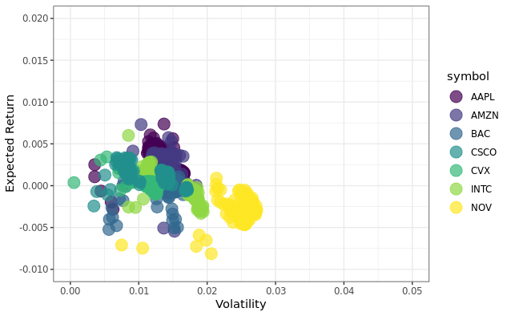

```r
p <- ggplot(sigmamusixmonth, aes(x = Sigma, y = Mu, colour = symbol)) +
  geom_point(show.legend = TRUE, alpha = 0.7, size = 5) +
  scale_color_viridis_d() +
  scale_size(range = c(2, 12)) +
  scale_x_log10() +
  labs(x = "Volatility", y = "Expected Return", colour = "symbol") +
  scale_y_continuous(breaks=seq(-0.3, 1, 0.005), limits = c(-0.01, 0.02)) +
  scale_x_continuous(breaks=seq(-0.3, 1, 0.01), limits = c(0, 0.05))
p

p + transition_time(date) +
  labs(title = "Year: {frame_time}")+
  shadow_wake(wake_length = 0.1, alpha = FALSE)
```

Expected return and volatility over 20 years mu/sigma

```r
sigmamustock_returns_monthly2000 <- fourstockselection %>%
  tq_get(get  = "stock.prices",
         from = "2000-01-01",
         to   = "2019-12-31") %>%
  group_by(symbol) %>%
  tq_transmute(select     = adjusted,
               mutate_fun = periodReturn,
               period     = "monthly",
               col_rename = "Stock.returns")

Mu2000monthly <- sigmamustock_returns_monthly2000 %>%
  tq_transmute(select = Stock.returns,
               mutate_fun = runMean,
               n = 10, cumulative = TRUE,
               col_rename = "Mu")
Sigma2000monthly <- sigmamustock_returns_monthly2000 %>%
  tq_transmute(select = Stock.returns,
               mutate_fun = runSD,
               n = 10, cumulative = TRUE,
               col_rename = "Sigma")

nasigmamu2000monthly <- left_join(Sigma2000monthly, Mu2000monthly)
sigmamu2000monthly <- na.omit(nasigmamu2000monthly)

library(ggplot2)
library(gganimate)
theme_set(theme_bw())
library(gapminder)

head(sigmamu2000monthly)
plotsigmamu2000 <- ggplot(sigmamu2000monthly, aes(x = Sigma, y = Mu, color = symbol)) +
  geom_point(show.legend = TRUE, alpha = 0.7,size = 5) +
  scale_color_viridis_d() +
  scale_size(range = c(2, 12)) +
  scale_x_log10() +
  labs(x = "Sigma", y = "MU", colour = "symbol")+
  scale_y_continuous(breaks=seq(-0.3, 1, 0.005), limits = c(-0.02, 0.06)) +
  scale_x_continuous(breaks=seq(-0.3, 1, 0.02), limits = c(0.1, 0.3))
plotsigmamu2000

plotsigmamu2000 + transition_time(date) +
  labs(title = "Year: {frame_time}") +
  shadow_wake(wake_length = 0.1, alpha = FALSE)
```

[output not shown]